# Investigating Changes in Whale Shark Abundnace in the Gulf of Mexico Over Time

Ana Bishop, Jasmime Papas, Tasneem Ahsanullah

2023-05-03

## Dataset Information

The Whale Shark Abundance data used in this analysis is from OBIS-SEAMAP. This was one of the only datasets that had multiple records over a long time period which is why we chose to use it. The whale shark data set spans from 1964 to 2010 and has 8,408 records of whale shark sightings. These sightings include chance encounters and individual catalogues. The encounters and photographs were mainly collected by the general public but the database is maintained by professional scientists.

The Sea Surface Temperature data is from the National Oceanic and Atmospheric Administration (NOAA). They have data on the global annual and monthly measure of sea surface temperature anomaly which is how different the temperature is from the average sea surface temperature. The time frame is from 1854 to present day and the data comes from the International Comprehensive Ocean-Atmosphere Dataset (ICODAS). We chose to download monthly data between the latitudes of 20N and 90N because that includes the Gulf of Mexico which is what we are interested in.

Table 1: Information on Datasets

| Dataset Name | Data Source | Data Range | Units | Variables used |
| --- | --- | --- | --- | --- |
| Whale Shark Abundance | OBIS-SEAMAP | 1964-2010 | Number of whale sharks | latitude, longitude, date-time |
| Sea Surface Temperature (Anomaly) | NOAA | 1854-Present | Kelvin | year, month, anomaly |

## Data Wrangling

First the whale shark dataset was filtered by latitude (17 to 30) and longitude (-98 to -79) to only include observations from the Gulf of Mexico. Date and time were separated into different columns and lubridate was used to turn the date into a date class. For the time series and linear regression analyses, we needed the count of whale sharks found each month. This was done by creating a column for just month and year. Then, a new column was created called total_sightings which was grouped by the month-year column. Lastly, the “distinct” function was used to only include the month-year column and sightings once for each month instead of for each day. Since, there is missing data points for certain months, we created a new data set of all the months between August 2002 and December 2009. This data set was then joined to the whale shark data set. All the months that didn’t have data were NA so for the time series the NAs were replaced with zeros.

The sea surface temperature data was wrangling by removing unnecessary columns and the time range was filtered to only include data between August 2002 and December 2009. A month-year column was made similar to the column created for the whale shark data. The sea surface temperature data was combined (using left_join) with the whale shark data using the month-year column and all NAs were omitted.

## Exploratory Analysis

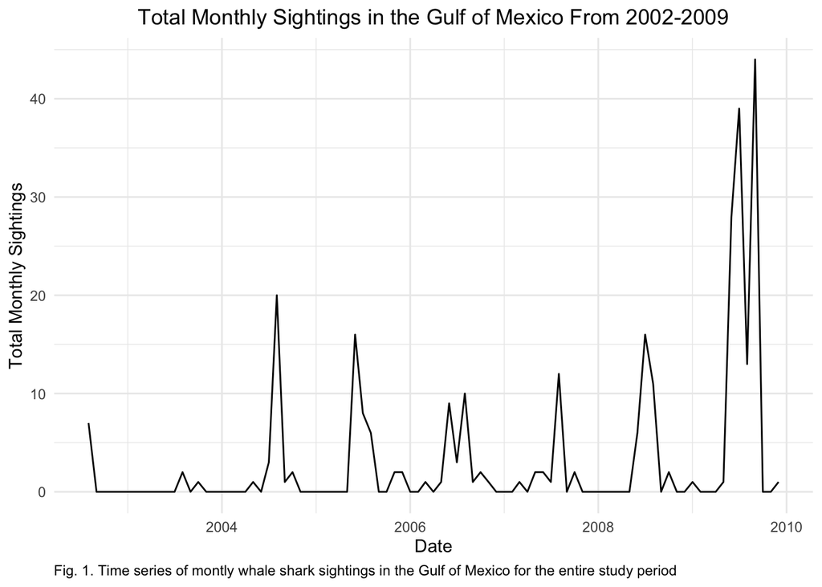

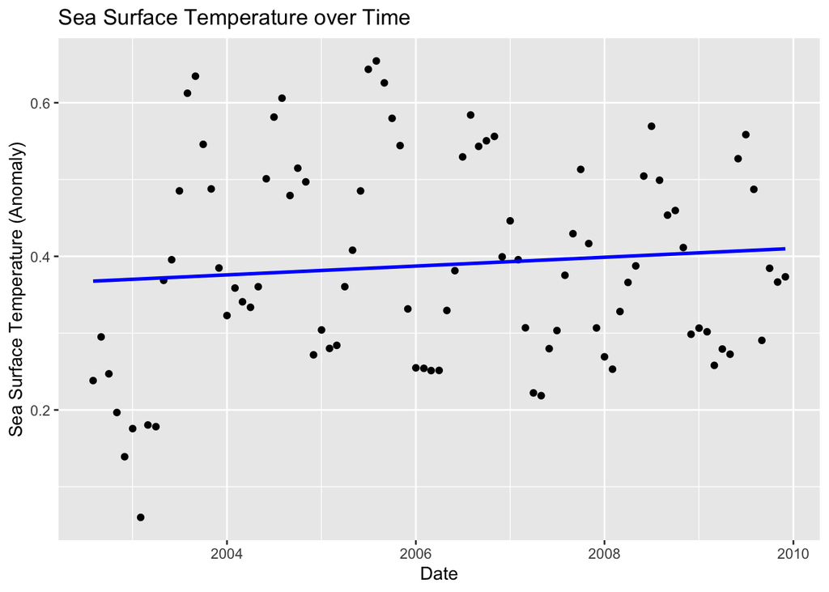

Figure 2. Shows that sea surface temperature anomaly is increasing slightly over time.

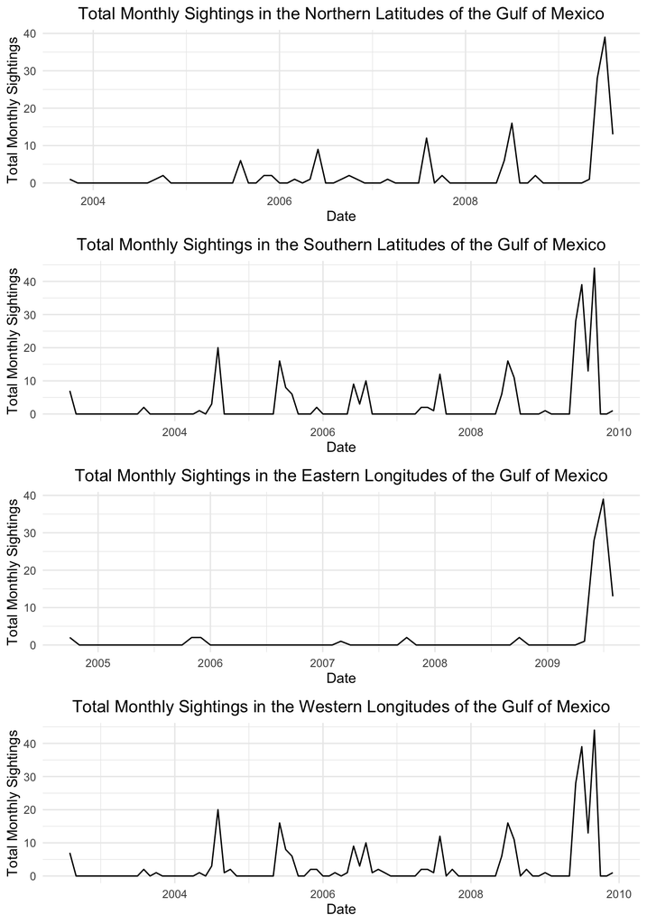

Figure 3. A four-panel comparison of whale shark sightings in the northern and southern halves of the Gulf of Mexico, followed by the Eastern and Western halves. Each category of sightings had different time periods associated with them, so note the differences in the x axes.

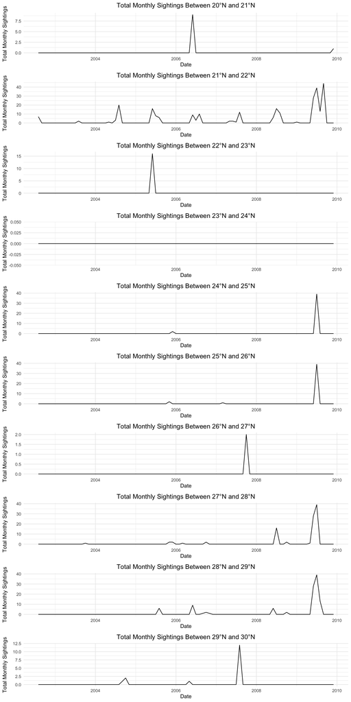

Figure 4. A comparison of whale shark sightings within each latitude parallel of the Gulf of Mexcio.

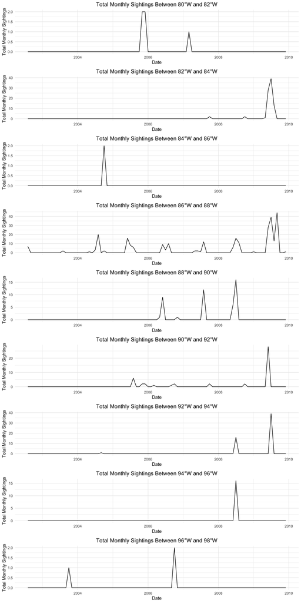

Figure 5. A comparison of whale shark sightings within every two longitude parallels of the Gulf of Mexico.